# Final Project - DTSA 5011

## Problem Statement

I want to explore different **object detection** algorithms on the **VisDrone** dataset, which is primarily for cars, bus, trucks, people, etc captured from various drones between 25-400 ft. AGL. My goal is to find a training strategy that performs well on this dataset so I can use it with my own personal drone.

- Data Source:
  - https://github.com/VisDrone/VisDrone-Dataset
  - Train
    - https://drive.google.com/file/d/1a2oHjcEcwXP8oUF95qiwrqzACb2YlUhn/view?usp=sharing
  - Valid
    - https://drive.google.com/file/d/1bxK5zgLn0_L8x276eKkuYA_FzwCIjb59/view?usp=sharing
- Data Details
  - I am using the Task 1 object detection in images challenge data. The task is to detect objects of certain categories:
    - car
    - bus
    - truck
    - pedestrian
    - awning-tricycle
    - ignored_regions
    - people
    - motor
    - bicycle
    - tricycle
    - van
    - others
  - There are over 7000 images with over 393,666 instances of objects in them.
- This VisDrone dataset description comes from:
  - https://github.com/VisDrone/VisDrone2018-DET-toolkit

```
<bbox_left>,<bbox_top>,<bbox_width>,<bbox_height>,<score>,<object_category>,<truncation>,<occlusion>


    Name                                                  Description
-------------------------------------------------------------------------------------------------------------------------------
 <bbox_left>	     The x coordinate of the top-left corner of the predicted bounding box

 <bbox_top>	     The y coordinate of the top-left corner of the predicted object bounding box

 <bbox_width>	     The width in pixels of the predicted object bounding box

<bbox_height>	     The height in pixels of the predicted object bounding box

   <score>	     The score in the DETECTION file indicates the confidence of the predicted bounding box enclosing
                     an object instance.
                     The score in GROUNDTRUTH file is set to 1 or 0. 1 indicates the bounding box is considered in evaluation,
                     while 0 indicates the bounding box will be ignored.

<object_category>    The object category indicates the type of annotated object, (i.e., ignored regions(0), pedestrian(1),
                     people(2), bicycle(3), car(4), van(5), truck(6), tricycle(7), awning-tricycle(8), bus(9), motor(10),
                     others(11))

<truncation>	     The score in the DETECTION result file should be set to the constant -1.
                     The score in the GROUNDTRUTH file indicates the degree of object parts appears outside a frame
                     (i.e., no truncation = 0 (truncation ratio 0%), and partial truncation = 1 (truncation ratio 1% ~ 50%)).

<occlusion>	     The score in the DETECTION file should be set to the constant -1.
                     The score in the GROUNDTRUTH file indicates the fraction of objects being occluded (i.e., no occlusion = 0
                     (occlusion ratio 0%), partial occlusion = 1 (occlusion ratio 1% ~ 50%), and heavy occlusion = 2
                     (occlusion ratio 50% ~ 100%)).
```

# 1. EDA

## 1.1 Import Libraries

```python
import os
import pandas as pd
import matplotlib.pyplot as plt
from tqdm import tqdm
import xml.etree.ElementTree as ET
from sklearn.model_selection import train_test_split
import shutil
import matplotlib.cm as cm
from PIL import Image
import matplotlib.patches as patches
```

## 1.2 Read in Data

```python
path_VisDrone_Yolo_Objs_train = r"VisDrone2019-DET-train"
path_VisDrone_Yolo_Objs_val = r"VisDrone2019-DET-val"
```

We have to define our classes upfront based on the instructions from the Github link since the are in enumerated format.

- https://github.com/VisDrone/VisDrone2018-DET-toolkit

```python
classes = {0:"ignored regions",
1:"pedestrian",
2:"people",
3:"bicycle",
4:"car",
5:"van",
6:"truck",
7:"tricycle",
8:"awning-tricycle",
9:"bus",
10:"motor",
11:"others"
}
```

We want to read in all of the training and validation images.

```python
train_imgs = os.listdir(os.path.join(path_VisDrone_Yolo_Objs_train,"images"))
train_imgs = [os.path.join(path_VisDrone_Yolo_Objs_train,"images",w) for w in train_imgs]
valid_imgs = os.listdir(os.path.join(path_VisDrone_Yolo_Objs_val,"images"))
valid_imgs = [os.path.join(path_VisDrone_Yolo_Objs_val,"images",w) for w in valid_imgs]
```

- We will create a function to help us read in the annotation files for each image following the format from the VisDrone dataset.
- The annotation files for VisDrone are originally **comma** separated, so we will split on the **comma** and parse in the following order:
  - **left**
    - The x coordinate of the top-left corner of the predicted bounding box
  - **top**
    - The y coordinate of the top-left corner of the predicted object bounding box
  - **w**
    - The width in pixels of the predicted object bounding box
  - **h**
    - The height in pixels of the predicted object bounding box
  - **score_i**
    - The score in the DETECTION file indicates the confidence of the predicted bounding box enclosing an object instance.
    - The score in GROUNDTRUTH file is set to 1 or 0. 1 indicates the bounding box is considered in evaluation, while 0 indicates the bounding box will be ignored.
  - **cat_i**
    - The object category indicates the type of annotated object,
      - ignored regions(0),
      - pedestrian(1),
      - people(2),
      - bicycle(3),
      - car(4),
      - van(5),
      - truck(6),
      - tricycle(7),
      - awning-tricycle(8),
      - bus(9),
      - motor(10),
      - others(11)
  - **trunc_i**
    - The score in the DETECTION result file should be set to the constant -1.
    - The score in the GROUNDTRUTH file indicates the degree of object parts appears outside a frame (i.e., no truncation = 0 (truncation ratio 0%), and partial truncation = 1 (truncation ratio 1% ~ 50%)).
  - **occ_i**
    - The score in the DETECTION file should be set to the constant -1.
    - The score in the GROUNDTRUTH file indicates the fraction of objects being occluded (i.e., no occlusion = 0 (occlusion ratio 0%), partial occlusion = 1 (occlusion ratio 1% ~ 50%), and heavy occlusion = 2 (occlusion ratio 50% ~ 100%)).
- We want to convert the VisDrone format to YOLO format.
  - YOLO format is a *space* seperated line by line *.txt* file per each image that contains all of the bounding boxes in each file.
  - Each image will have a single *.txt* file that should have the following for lines for each object in it separated by *space*:
  - Example, **yolo_line = f"{int(cat_i)} {xc_n} {yc_n} {w_n} {h_n}"**
    - **cat_i**
      - The object category similar format as VisDrone **cat_i**
    - **xc_n**
      - The normalized center point on the x-axis of the object (i.e. (xmin+xmax)/(image_width * 2.0))
    - **yc_n**
      - The normalized center point on the y-axis of the object (i.e. (ymin+ymax)/(image_height * 2.0))
    - **w_n**
      - The normalized width of the bounding box (i.e. (w/image_width))
    - **h_n**
      - The normalized height of the bounding box (i.e. (h/image_height))
- We will create a Pandas DataFrame of our data read and save off to *.csv* for time saving later:
  - **df_train.csv**
    - The training images/annotations from VisDrone read in and converted into YOLO format.
  - **df_val.csv**
    - The validation images/annotations from VisDrone read in and converted into YOLO format.

```python
def read_in_VisDrone(img_list,classes):
    df = pd.DataFrame(columns=['img_path','img_h','img_w','xmin','xmax','ymin','ymax','left','top','w','h','score_i','cat_i','trunc_i','occ_i','label_i',"yolo_line"])
    for i, img_i in tqdm(enumerate(img_list)):
        anno_i = img_i.replace("images","annotations").split(".")[0]+".txt"
        f=open(anno_i)
        f_read=f.readlines()
        f.close()
        img_j = plt.imread(img_i)
        img_h,img_w,_ = img_j.shape
        for line in f_read:
            left,top,w,h,score_i,cat_i,trunc_i,occ_i=line.replace(',\n','').split(',')
            j = len(df)
            df.at[j,'img_path'] = img_i
            df.at[j,'left']=left
            df.at[j,'top']=top
            df.at[j,'w']=w
            df.at[j,'h']=h
            df.at[j,'score_i']=score_i
            df.at[j,'cat_i']=cat_i
            df.at[j,'trunc_i']=trunc_i
            df.at[j,'occ_i']=occ_i.strip()
            x1=float(left)
            x2=float(left)+float(w)
            y1=float(top)
            y2=float(top)+float(h)
            df.at[j,'xmin']=x1
            df.at[j,'xmax']=x2
            df.at[j,'ymin']=y1
            df.at[j,'ymax']=y2
            df.at[j,'label_i']=classes[int(cat_i)]
            xc = (x1+x2)/2.0
            yc = (y1+y2)/2.0
            xc_n = xc/img_w
            yc_n = yc/img_h
            df.at[j,'img_h']=img_h
            df.at[j,'img_w']=img_w
            w_n = float(w)/img_w
            h_n = float(h)/img_h
            yolo_line = f"{int(cat_i)} {xc_n} {yc_n} {w_n} {h_n}"
            df.at[j,"yolo_line"] = yolo_line
    return df
```

```python
if os.path.exists("df_train.csv")==False:
    df_train = read_in_VisDrone(train_imgs,classes)
    df_train.to_csv("df_train.csv",index=None)
else:
    df_train = pd.read_csv("df_train.csv",index_col=None)
if os.path.exists("df_val.csv")==False:
    df_val = read_in_VisDrone(valid_imgs,classes)
    df_val.to_csv("df_val.csv",index=None)
else:
    df_val = pd.read_csv("df_val.csv",index_col=None)
```

- Notice, we have 353,550 instances in our training dataset **df_train.csv** and 40,169 instances in our validation dataset **df_val.csv**

```python
df_train
```

|  | img_path | img_h | img_w | xmin | xmax | ymin | ymax | left | top | w | h | score_i | cat_i | trunc_i | occ_i | label_i | yolo_line |
| --- | --- | --- | --- | --- | --- | --- | --- | --- | --- | --- | --- | --- | --- | --- | --- | --- | --- |
| 0 | VisDrone2019-DET-train/images/9999960_00000_d_... | 1050 | 1400 | 246.0 | 386.0 | 871.0 | 1050.0 | 246 | 871 | 140 | 179 | 1 | 4 | 1 | 1 | car | 4 0.2257142857142857 0.9147619047619048 0.1 0.... |
| 1 | VisDrone2019-DET-train/images/9999960_00000_d_... | 1050 | 1400 | 780.0 | 886.0 | 741.0 | 906.0 | 780 | 741 | 106 | 165 | 1 | 4 | 0 | 0 | car | 4 0.595 0.7842857142857143 0.07571428571428572... |
| 2 | VisDrone2019-DET-train/images/9999960_00000_d_... | 1050 | 1400 | 851.0 | 937.0 | 581.0 | 711.0 | 851 | 581 | 86 | 130 | 1 | 4 | 0 | 0 | car | 4 0.6385714285714286 0.6152380952380953 0.0614... |
| 3 | VisDrone2019-DET-train/images/9999960_00000_d_... | 1050 | 1400 | 400.0 | 503.0 | 681.0 | 807.0 | 400 | 681 | 103 | 126 | 1 | 4 | 0 | 0 | car | 4 0.3225 0.7085714285714285 0.0735714285714285... |
| 4 | VisDrone2019-DET-train/images/9999960_00000_d_... | 1050 | 1400 | 497.0 | 598.0 | 521.0 | 639.0 | 497 | 521 | 101 | 118 | 1 | 4 | 0 | 0 | car | 4 0.39107142857142857 0.5523809523809524 0.072... |
| ... | ... | ... | ... | ... | ... | ... | ... | ... | ... | ... | ... | ... | ... | ... | ... | ... | ... |
| 353545 | VisDrone2019-DET-train/images/9999960_00000_d_... | 1050 | 1400 | 911.0 | 948.0 | 665.0 | 709.0 | 911 | 665 | 37 | 44 | 1 | 4 | 0 | 0 | car | 4 0.6639285714285714 0.6542857142857142 0.0264... |
| 353546 | VisDrone2019-DET-train/images/9999960_00000_d_... | 1050 | 1400 | 908.0 | 944.0 | 631.0 | 671.0 | 908 | 631 | 36 | 40 | 1 | 4 | 0 | 1 | car | 4 0.6614285714285715 0.62 0.025714285714285714... |
| 353547 | VisDrone2019-DET-train/images/9999960_00000_d_... | 1050 | 1400 | 901.0 | 934.0 | 596.0 | 633.0 | 901 | 596 | 33 | 37 | 1 | 4 | 0 | 1 | car | 4 0.6553571428571429 0.5852380952380952 0.0235... |
| 353548 | VisDrone2019-DET-train/images/9999960_00000_d_... | 1050 | 1400 | 919.0 | 949.0 | 567.0 | 601.0 | 919 | 567 | 30 | 34 | 1 | 4 | 0 | 1 | car | 4 0.6671428571428571 0.5561904761904762 0.0214... |
| 353549 | VisDrone2019-DET-train/images/9999960_00000_d_... | 1050 | 1400 | 901.0 | 925.0 | 360.0 | 384.0 | 901 | 360 | 24 | 24 | 1 | 4 | 0 | 0 | car | 4 0.6521428571428571 0.35428571428571426 0.017... |

353550 rows × 17 columns

```python
df_val
```

|  | img_path | img_h | img_w | xmin | xmax | ymin | ymax | left | top | w | h | score_i | cat_i | trunc_i | occ_i | label_i | yolo_line |
| --- | --- | --- | --- | --- | --- | --- | --- | --- | --- | --- | --- | --- | --- | --- | --- | --- | --- |
| 0 | VisDrone2019-DET-val/images/0000289_01401_d_00... | 765 | 1360 | 621.0 | 726.0 | 425.0 | 687.0 | 621 | 425 | 105 | 262 | 1 | 9 | 0 | 0 | bus | 9 0.49522058823529413 0.726797385620915 0.0772... |
| 1 | VisDrone2019-DET-val/images/0000289_01401_d_00... | 765 | 1360 | 408.0 | 485.0 | 586.0 | 732.0 | 408 | 586 | 77 | 146 | 1 | 4 | 0 | 1 | car | 4 0.32830882352941176 0.8614379084967321 0.056... |
| 2 | VisDrone2019-DET-val/images/0000289_01401_d_00... | 765 | 1360 | 530.0 | 556.0 | 671.0 | 727.0 | 530 | 671 | 26 | 56 | 1 | 10 | 0 | 1 | motor | 10 0.39926470588235297 0.9137254901960784 0.01... |
| 3 | VisDrone2019-DET-val/images/0000289_01401_d_00... | 765 | 1360 | 532.0 | 556.0 | 656.0 | 708.0 | 532 | 656 | 24 | 52 | 1 | 1 | 0 | 1 | pedestrian | 1 0.4 0.8915032679738563 0.01764705882352941 0... |
| 4 | VisDrone2019-DET-val/images/0000289_01401_d_00... | 765 | 1360 | 513.0 | 530.0 | 544.0 | 591.0 | 513 | 544 | 17 | 47 | 1 | 1 | 0 | 0 | pedestrian | 1 0.3834558823529412 0.7418300653594772 0.0125... |
| ... | ... | ... | ... | ... | ... | ... | ... | ... | ... | ... | ... | ... | ... | ... | ... | ... | ... |
| 40164 | VisDrone2019-DET-val/images/0000256_00715_d_00... | 765 | 1360 | 174.0 | 238.0 | 203.0 | 260.0 | 174 | 203 | 64 | 57 | 0 | 0 | 0 | 0 | ignored regions | 0 0.1514705882352941 0.3026143790849673 0.0470... |
| 40165 | VisDrone2019-DET-val/images/0000256_00715_d_00... | 765 | 1360 | 226.0 | 333.0 | 179.0 | 229.0 | 226 | 179 | 107 | 50 | 0 | 0 | 0 | 0 | ignored regions | 0 0.20551470588235293 0.26666666666666666 0.07... |
| 40166 | VisDrone2019-DET-val/images/0000256_00715_d_00... | 765 | 1360 | 292.0 | 329.0 | 220.0 | 268.0 | 292 | 220 | 37 | 48 | 0 | 0 | 0 | 0 | ignored regions | 0 0.22830882352941176 0.31895424836601305 0.02... |
| 40167 | VisDrone2019-DET-val/images/0000256_00715_d_00... | 765 | 1360 | 432.0 | 460.0 | 227.0 | 267.0 | 432 | 227 | 28 | 40 | 0 | 0 | 0 | 0 | ignored regions | 0 0.32794117647058824 0.32287581699346407 0.02... |
| 40168 | VisDrone2019-DET-val/images/0000256_00715_d_00... | 765 | 1360 | 421.0 | 445.0 | 237.0 | 248.0 | 421 | 237 | 24 | 11 | 0 | 0 | 0 | 0 | ignored regions | 0 0.31838235294117645 0.31699346405228757 0.01... |

40169 rows × 17 columns

## 1.2.1 Visualize Data Counts

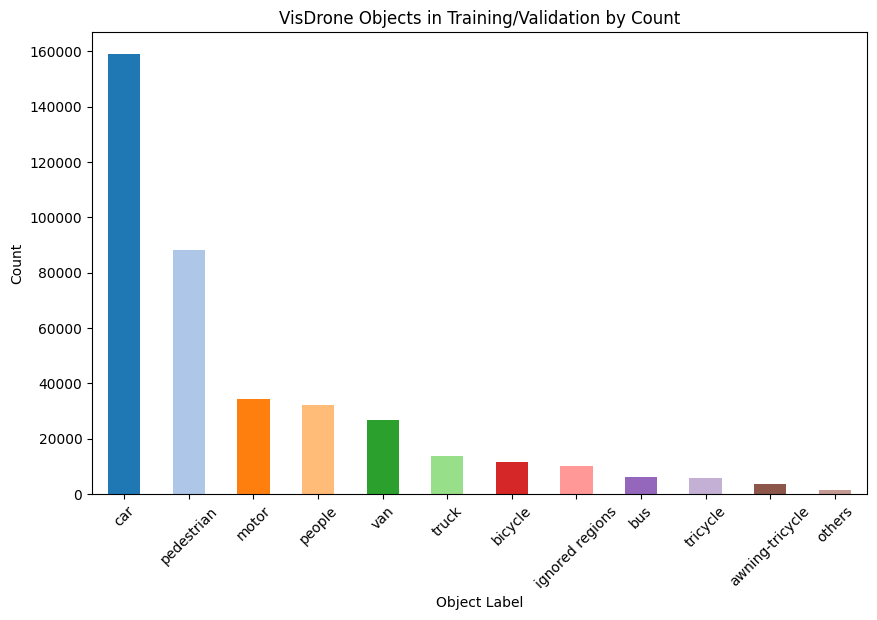

```python
df = pd.concat([df_train,df_val],axis=0,ignore_index=True)
label_counts = df['label_i'].value_counts()
colors = cm.tab20.colors  # Use 'tab20' colormap which has 20 distinct colors
color_map = {label: colors[i % len(colors)] for i, label in enumerate(label_counts.index)}

# Plot a histogram with unique colors for each category
plt.figure(figsize=(10, 6))
label_counts.plot(kind='bar', color=[color_map[label] for label in label_counts.index])
plt.xlabel('Object Label')
plt.ylabel('Count')
plt.title('VisDrone Objects in Training/Validation by Count')
plt.xticks(rotation=45)
plt.show()
```

## 1.2.2 Visualize Example

- Let's read in an image and plot its bounding boxex over the image to ensure we know what we are working with.

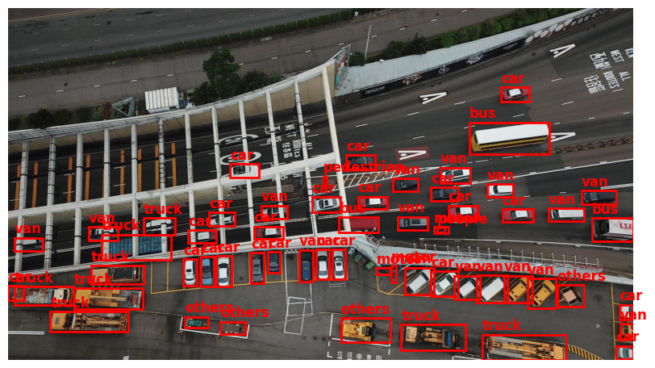

```python
img_path = df['img_path'][200]
image = Image.open(img_path)
fig, ax = plt.subplots(figsize=(10, 10))
ax.imshow(image)
df_i = df[df["img_path"]==img_path].copy()
for _, row in df_i.iterrows():
    xmin, ymin = row['xmin'], row['ymin']
    width = row['xmax'] - row['xmin']
    height = row['ymax'] - row['ymin']

    rect = patches.Rectangle((xmin, ymin), width, height, linewidth=2, edgecolor='r', facecolor='none')
    ax.add_patch(rect)
    ax.text(xmin, ymin - 10, row['label_i'], color='red', fontsize=12, weight='bold')

plt.axis('off')
plt.show()
```

```python
df_val.describe()
```

|  | img_h | img_w | xmin | xmax | ymin | ymax | left | top | w | h | score_i | cat_i | trunc_i | occ_i |
| --- | --- | --- | --- | --- | --- | --- | --- | --- | --- | --- | --- | --- | --- | --- |
| count | 40169.000000 | 40169.000000 | 40169.000000 | 40169.000000 | 40169.000000 | 40169.000000 | 40169.000000 | 40169.000000 | 40169.000000 | 40169.000000 | 40169.000000 | 40169.000000 | 40169.000000 | 40169.000000 |
| mean | 733.244915 | 1303.546516 | 626.660460 | 658.733924 | 265.132938 | 296.816251 | 626.660460 | 265.132938 | 32.073465 | 31.683313 | 0.964898 | 3.899226 | 0.036670 | 0.623615 |
| std | 112.733925 | 200.415867 | 311.244037 | 313.984837 | 176.036486 | 186.594355 | 311.244037 | 176.036486 | 33.782460 | 24.441726 | 0.184039 | 2.864766 | 0.187953 | 0.623201 |
| min | 540.000000 | 960.000000 | 0.000000 | 8.000000 | 0.000000 | 4.000000 | 0.000000 | 0.000000 | 2.000000 | 2.000000 | 0.000000 | 0.000000 | 0.000000 | 0.000000 |
| 25% | 765.000000 | 1360.000000 | 410.000000 | 436.000000 | 133.000000 | 156.000000 | 410.000000 | 133.000000 | 11.000000 | 17.000000 | 1.000000 | 1.000000 | 0.000000 | 0.000000 |
| 50% | 765.000000 | 1360.000000 | 610.000000 | 636.000000 | 236.000000 | 264.000000 | 610.000000 | 236.000000 | 21.000000 | 26.000000 | 1.000000 | 4.000000 | 0.000000 | 1.000000 |
| 75% | 765.000000 | 1360.000000 | 833.000000 | 867.000000 | 367.000000 | 403.000000 | 833.000000 | 367.000000 | 41.000000 | 39.000000 | 1.000000 | 4.000000 | 0.000000 | 1.000000 |
| max | 1080.000000 | 1920.000000 | 1884.000000 | 1920.000000 | 1054.000000 | 1080.000000 | 1884.000000 | 1054.000000 | 594.000000 | 616.000000 | 1.000000 | 11.000000 | 1.000000 | 2.000000 |

```python
df_train.describe()
```

|  | img_h | img_w | xmin | xmax | ymin | ymax | left | top | w | h | score_i | cat_i | trunc_i | occ_i |
| --- | --- | --- | --- | --- | --- | --- | --- | --- | --- | --- | --- | --- | --- | --- |
| count | 353550.00000 | 353550.000000 | 353550.000000 | 353550.000000 | 353550.000000 | 353550.000000 | 353550.000000 | 353550.000000 | 353550.000000 | 353550.000000 | 353550.000000 | 353550.000000 | 353550.000000 | 353550.000000 |
| mean | 1012.52975 | 1539.368632 | 741.608811 | 780.717463 | 394.327026 | 431.847128 | 741.608811 | 394.327026 | 39.108652 | 37.520102 | 0.970740 | 3.882622 | 0.038060 | 0.595336 |
| std | 248.51723 | 286.179203 | 381.570264 | 384.316805 | 269.527223 | 282.262141 | 381.570264 | 269.527223 | 41.860851 | 34.210746 | 0.168536 | 2.622263 | 0.191341 | 0.657372 |
| min | 360.00000 | 480.000000 | 0.000000 | 5.000000 | 0.000000 | 2.000000 | 0.000000 | 0.000000 | 2.000000 | 0.000000 | 0.000000 | 0.000000 | 0.000000 | 0.000000 |
| 25% | 788.00000 | 1400.000000 | 474.000000 | 509.000000 | 184.000000 | 211.000000 | 474.000000 | 184.000000 | 13.000000 | 17.000000 | 1.000000 | 2.000000 | 0.000000 | 0.000000 |
| 50% | 1050.00000 | 1400.000000 | 725.000000 | 757.000000 | 349.000000 | 382.500000 | 725.000000 | 349.000000 | 26.000000 | 27.000000 | 1.000000 | 4.000000 | 0.000000 | 0.000000 |
| 75% | 1078.00000 | 1916.000000 | 993.000000 | 1031.000000 | 566.000000 | 608.000000 | 993.000000 | 566.000000 | 49.000000 | 46.000000 | 1.000000 | 4.000000 | 0.000000 | 1.000000 |
| max | 1500.00000 | 2000.000000 | 1993.000000 | 2000.000000 | 1488.000000 | 1500.000000 | 1993.000000 | 1488.000000 | 1424.000000 | 790.000000 | 1.000000 | 11.000000 | 1.000000 | 2.000000 |

## 1.3 Create YOLO Training Data

- We want to convert each of these instances into a YOLO *.txt* file for training/validation.
  - We need to make a single *.txt* file for each unique YOLO image.
    - So we will create a unique dataframe, **df_i** to temporarily hold the instances associated with a single image.
  - We will only create the *.txt* file if it doesn't exist in the output directory, **VisDroneYOLO**

```python
path_VisDroneYOLO = "VisDroneYOLO"
if os.path.exists(path_VisDroneYOLO)==False:
    os.makedirs(path_VisDroneYOLO)
files_found=os.listdir(path_VisDroneYOLO)
val_imgs = [os.path.basename(w) for w in df_val["img_path"]]
val_annos = [w.split(".")[0]+".txt" for w in val_imgs]
for img_i  in tqdm(val_imgs):
    anno_i = img_i.split(".")[0]+".txt"
    if img_i not in files_found:
        img_i_abs_path = os.path.join(path_VisDrone_Yolo_Objs_val,"images",img_i)
        shutil.copy(img_i_abs_path,path_VisDroneYOLO)
    if anno_i not in files_found:
        img_i_abs_path = os.path.join(path_VisDrone_Yolo_Objs_val,"images",img_i)
        df_i = df_val[df_val["img_path"]==img_i_abs_path].copy()
        df_i = df_i.reset_index().drop("index",axis=1)
        yolo_file_i = ""
        for i in range(len(df_i)):
            if i==0:
                yolo_file_i = df_i.yolo_line.loc[i] + "\n"
            else:
                yolo_file_i = yolo_file_i + df_i.yolo_line.loc[i] + "\n"
        output_yolo_file_i = os.path.join(path_VisDroneYOLO,anno_i)
        with open(output_yolo_file_i,"w") as f:
            f.write(yolo_file_i)
train_imgs = [os.path.basename(w) for w in df_train["img_path"]]
train_annos = [w.split(".")[0]+".txt" for w in train_imgs]
for img_i  in tqdm(train_imgs):
    anno_i = img_i.split(".")[0]+".txt"
    if img_i not in files_found:
        img_i_abs_path = os.path.join(path_VisDrone_Yolo_Objs_train,"images",img_i)
        shutil.copy(img_i_abs_path,path_VisDroneYOLO)
    if anno_i not in files_found:
        img_i_abs_path = os.path.join(path_VisDrone_Yolo_Objs_train,"images",img_i)
        df_i = df_train[df_train["img_path"]==img_i_abs_path].copy()
        df_i = df_i.reset_index().drop("index",axis=1)
        yolo_file_i = ""
        for i in range(len(df_i)):
            if i==0:
                yolo_file_i = df_i.yolo_line.loc[i] + "\n"
            else:
                yolo_file_i = yolo_file_i + df_i.yolo_line.loc[i] + "\n"
        output_yolo_file_i = os.path.join(path_VisDroneYOLO,anno_i)
        with open(output_yolo_file_i,"w") as f:
            f.write(yolo_file_i)
```

- We want to convert to combine then shuffle/split our data for training/validation/testing

```python
Yolo_Objs = sorted(os.listdir(path_VisDroneYOLO))
Yolo_Objs_jpg = [w for w in Yolo_Objs if w.endswith(".jpg")]
Yolo_Objs_txt = [w for w in Yolo_Objs if w.endswith(".txt")]
```

```python
print(len(Yolo_Objs_jpg))
print(len(Yolo_Objs_txt))
```

```
7019
7019
```

```python
dataset = [os.path.join(path_VisDroneYOLO,w) for w in Yolo_Objs_jpg]
dataset = sorted(dataset)
len(dataset)
```

```
7019
```

```python
# Perform train-test split
train_list, val_test_list = train_test_split(dataset, test_size=0.2, random_state=42)
val_list, test_list = train_test_split(val_test_list, test_size=0.5, random_state=42)

print("len(Train List):", len(train_list))
print("len(Valid List):", len(val_list))
print("len(Test List):", len(test_list))
```

```
len(Train List): 5615
len(Valid List): 702
len(Test List): 702
```

- Training YOLO can use single files for *train*, *val*, and *test* that go into the **yaml** file we have to make for training.
- These files will contain the absolute path to our images.
  - Caution, each image absolute path should have a *.txt* file next to it in the directory it resides, but you don't have to write that to this file. YOLO knows how to find it from that image's absolute path.

```python
def create_list_file(list_i,filename_i):
    with open(filename_i,"w") as f:
        for line in list_i:
            f.writelines(line+"\n")
path_train_list = "train_list.txt"
path_valid_list = "valid_list.txt"
path_test_list = "test_list.txt"
create_list_file(train_list,path_train_list)
create_list_file(val_list,path_valid_list)
create_list_file(test_list,path_test_list)
```

# 2. Analysis - Model Building/Training

## 2.1 Feature Selection/Engineering

- We will select the **names** we want to train on from the dataset as our main features.
  - We could combine classes, but we will just train on the objects as they are for now.
- We create our YAML file for training.
  - **names**
    - This is the names as they appear in the YOLO *.txt* files.
    - Make sure your mapping from the YOLO *.txt* file is correct between the enumerated values here and the names you explicitly write in the YAML.
  - **train**
    - This is the absolute path to the train list we made earlier.
  - **val**
    - This is the absolute path to the val list we made earlier.
  - **test**
    - This is the absolute path to the test list we made earlier.

```python
data = f'''names:
    0: ignored regions
    1: pedestrian
    2: people
    3: bicycle
    4: car
    5: van
    6: truck
    7: tricycle
    8: awning-tricycle
    9: bus
    10: motor
    11: others

train: {os.path.abspath(path_train_list)}
val: {os.path.abspath(path_valid_list)}
test: {os.path.abspath(path_test_list)}
'''
```

```python
path_train_data_yaml = "train_data.yaml"
with open(path_train_data_yaml, 'w') as file:
    file.write(str(data))
```

## 2.2 Model Matrix - Training

- We will create multiple different models, exploring different algorithms and hyperparameters:
  - architecture
    - yolo11
      - Latest as of 10/24/2024 in Ultralytics for YOLO
      - Key Features (source https://docs.ultralytics.com/models/yolo11/#key-features)
        - Enhanced Feature Extraction: YOLO11 employs an improved backbone and neck architecture, which enhances feature extraction capabilities for more precise object detection and complex task performance.
        - Optimized for Efficiency and Speed: YOLO11 introduces refined architectural designs and optimized training pipelines, delivering faster processing speeds and maintaining an optimal balance between accuracy and performance.
        - Greater Accuracy with Fewer Parameters: With advancements in model design, YOLO11m achieves a higher mean Average Precision (mAP) on the COCO dataset while using 22% fewer parameters than YOLOv8m, making it computationally efficient without compromising accuracy.
        - Adaptability Across Environments: YOLO11 can be seamlessly deployed across various environments, including edge devices, cloud platforms, and systems supporting NVIDIA GPUs, ensuring maximum flexibility.
        - Broad Range of Supported Tasks: Whether it's object detection, instance segmentation, image classification, pose estimation, or oriented object detection (OBB), YOLO11 is designed to cater to a diverse set of computer vision challenges.
    - yolov10
      - Key Features (source https://docs.ultralytics.com/models/yolov10/#key-features)
        - NMS-Free Training: Utilizes consistent dual assignments to eliminate the need for NMS, reducing inference latency.
        - Holistic Model Design: Comprehensive optimization of various components from both efficiency and accuracy perspectives, including lightweight classification heads, spatial-channel decoupled down sampling, and rank-guided block design.
        - Enhanced Model Capabilities: Incorporates large-kernel convolutions and partial self-attention modules to improve performance without significant computational cost.
    - yolov8
      - Key Features (source https://docs.ultralytics.com/models/yolov8/#key-features)
        - Advanced Backbone and Neck Architectures: YOLOv8 employs state-of-the-art backbone and neck architectures, resulting in improved feature extraction and object detection performance.
        - Anchor-free Split Ultralytics Head: YOLOv8 adopts an anchor-free split Ultralytics head, which contributes to better accuracy and a more efficient detection process compared to anchor-based approaches.
        - Optimized Accuracy-Speed Tradeoff: With a focus on maintaining an optimal balance between accuracy and speed, YOLOv8 is suitable for real-time object detection tasks in diverse application areas.
        - Variety of Pre-trained Models: YOLOv8 offers a range of pre-trained models to cater to various tasks and performance requirements, making it easier to find the right model for your specific use case.
  - imgsz
    - 1280
    - 640
  - batch
    - 16 (default)
    - 4
    - 2
    - 1
  - Model Variants
    - **s**
      - *small* architecture
      - Balances speed and accuracy
    - **m**
      - *medium* architecture
      - general-purpose use
    - **l**
      - *large* architecture
      - higher accuracy at the cost of increased computational resources.

```python
project = "VisDrone_Models_P5"
train_scripts = f'''yolo train model=yolo11s.pt data={path_train_data_yaml} project={project} name=yolov11s_640 epochs=100 imgsz=640 patience=5 device=0
yolo train model=yolo11s.pt data=train_data.yaml project=VisDrone_Models_P5 name=yolov11s_640 epochs=100 imgsz=640 patience=5 device=0 batch=16
yolo train model=yolov8s.pt data=train_data.yaml project=VisDrone_Models_P5 epochs=100 name=yolov8s_640 imgsz=640 patience=5 device=0 batch=16
yolo train model=yolov10s.pt data=train_data.yaml project=VisDrone_Models_P5 epochs=100 name=yolov10s_640 imgsz=640 patience=5 device=0 batch=8
yolo train model=yolo11s.pt data=train_data.yaml project=VisDrone_Models_P5 name=yolov11s_1280 epochs=100 imgsz=1280 patience=5 device=0 batch=4
yolo train model=yolov8s.pt data=train_data.yaml project=VisDrone_Models_P5 epochs=100 name=yolov8s_1280 imgsz=1280 patience=5 device=0 batch=4
yolo train model=yolov10s.pt data=train_data.yaml project=VisDrone_Models_P5 epochs=100 name=yolov10s_1280 imgsz=1280 patience=5 device=0 batch=2
yolo train model=yolo11m.pt data=train_data.yaml project=VisDrone_Models_P5 name=yolov11m_1280 epochs=100 imgsz=1280 patience=5 device=0 batch=2
yolo train model=yolov8m.pt data=train_data.yaml project=VisDrone_Models_P5 epochs=100 name=yolov8m_1280 imgsz=1280 patience=5 device=0 batch=2
yolo train model=yolov10m.pt data=train_data.yaml project=VisDrone_Models_P5 epochs=100 name=yolov10m_1280 imgsz=1280 patience=5 device=0 batch=2
yolo train model=yolo11l.pt data=train_data.yaml project=VisDrone_Models_P5 name=yolov11l_1280 epochs=100 imgsz=1280 patience=5 device=0 batch=1

'''
path_train_scripts = "train_scripts.sh"
CREATE_SCRIPT = False
if CREATE_SCRIPT:
    with open(path_train_scripts,"w") as f:
        f.write(str(train_scripts))
```

- We can run a **nohup** command on our training script in order to train the models outside of this notebook.

```python
RUN_MODEL_MATRIX = False
if RUN_MODEL_MATRIX:
    os.system("nohup bash train_scripts.sh > train_scripts.log 2>&1 &")
```

# 3.0 Results

## 3.1 Read in Results

- We will read in each result path from our trained models.

```python
results_path = "/mnt/DATA1/DTSA_5011/Final_Project/VisDrone_Models_P5"
models = os.listdir(results_path)
models = [w for w in models if os.path.exists(os.path.join(results_path,w,"results.csv"))]
```

- Notice we made the following models:

```python
models
```

```
['yolov11m_1280',
 'yolov8s_1280',
 'yolov11l_1280',
 'yolov8s_640',
 'yolov10s_640',
 'yolov10s_1280',
 'yolov11s_1280',
 'yolov11s_640']
```

- We can read in those result files and make a Pandas DataFrame to analyze results

```python
for i,model in enumerate(models):
    df_i = pd.read_csv(os.path.join(results_path,model,"results.csv"))
    df_i["model"] = model
    cols = df_i.columns
    new_cols = {k:k.replace(" ","") for k in cols}
    df_i = df_i.rename(columns=new_cols)
    if i==0:
        df = df_i.copy()
    else:
        df = pd.concat([df,df_i],axis=0,ignore_index=True)

df
```

|  | epoch | time | train/box_loss | train/cls_loss | train/dfl_loss | metrics/precision(B) | metrics/recall(B) | metrics/mAP50(B) | metrics/mAP50-95(B) | val/box_loss | val/cls_loss | val/dfl_loss | lr/pg0 | lr/pg1 | lr/pg2 | model |
| --- | --- | --- | --- | --- | --- | --- | --- | --- | --- | --- | --- | --- | --- | --- | --- | --- |
| 0 | 1 | 1275.70 | 1.37380 | 1.37976 | 1.04843 | 0.48880 | 0.33871 | 0.32963 | 0.20237 | 1.30300 | 1.13264 | 1.02784 | 0.000208 | 0.000208 | 0.000208 | yolov11m_1280 |
| 1 | 2 | 2493.84 | 1.36566 | 1.19797 | 1.04772 | 0.51298 | 0.34750 | 0.35558 | 0.21549 | 1.31169 | 1.08557 | 1.03047 | 0.000412 | 0.000412 | 0.000412 | yolov11m_1280 |
| 2 | 3 | 3806.02 | 1.35507 | 1.17263 | 1.04517 | 0.52197 | 0.36521 | 0.36211 | 0.22188 | 1.29422 | 1.06433 | 1.01998 | 0.000613 | 0.000613 | 0.000613 | yolov11m_1280 |
| 3 | 4 | 5029.76 | 1.34507 | 1.12704 | 1.03964 | 0.45049 | 0.38338 | 0.38546 | 0.23425 | 1.28218 | 1.04177 | 1.01584 | 0.000606 | 0.000606 | 0.000606 | yolov11m_1280 |
| 4 | 5 | 6256.03 | 1.32585 | 1.09608 | 1.03090 | 0.48899 | 0.39456 | 0.40322 | 0.24955 | 1.25881 | 0.98812 | 1.00152 | 0.000600 | 0.000600 | 0.000600 | yolov11m_1280 |
| ... | ... | ... | ... | ... | ... | ... | ... | ... | ... | ... | ... | ... | ... | ... | ... | ... |
| 503 | 39 | 7137.52 | 1.25839 | 0.86331 | 0.89689 | 0.47061 | 0.35196 | 0.35388 | 0.20740 | 1.24773 | 0.88159 | 0.89303 | 0.000390 | 0.000390 | 0.000390 | yolov11s_640 |
| 504 | 40 | 7312.03 | 1.26111 | 0.86420 | 0.89377 | 0.49730 | 0.34117 | 0.35430 | 0.20722 | 1.24443 | 0.88279 | 0.89339 | 0.000384 | 0.000384 | 0.000384 | yolov11s_640 |
| 505 | 41 | 7486.33 | 1.25407 | 0.85586 | 0.89468 | 0.47562 | 0.35101 | 0.35748 | 0.20805 | 1.25160 | 0.87493 | 0.89367 | 0.000378 | 0.000378 | 0.000378 | yolov11s_640 |
| 506 | 42 | 7660.76 | 1.24479 | 0.85242 | 0.89534 | 0.45063 | 0.36420 | 0.35885 | 0.20880 | 1.24181 | 0.87803 | 0.89373 | 0.000371 | 0.000371 | 0.000371 | yolov11s_640 |
| 507 | 43 | 7847.52 | 1.24618 | 0.84422 | 0.89320 | 0.47072 | 0.35499 | 0.35738 | 0.20867 | 1.24763 | 0.87431 | 0.89368 | 0.000365 | 0.000365 | 0.000365 | yolov11s_640 |

508 rows × 16 columns

- We can make a summary of the results, **df_summary** by **model**
  - sort values by the top **mAP50-95(B)**
- Notice, that the bigger architectures generally performed better
  - i.e. yolov11m performed better than yolov11s
- Notice, the larger input sizes performed better
  - i.e. 1280 input did better than 640 across the board
- Notice, no significant difference between yolov11, yolov10, yolov8 with all other things constant.
  - i.e., yolov8s_1280 did similar to yolov11s_1280 and yolov10s_1280

```python
df_summary = df.sort_values(by="metrics/mAP50-95(B)",ascending=False).drop_duplicates(["model"],keep="first").reset_index().drop("index",axis=1)
df_summary.sort_values(by="metrics/mAP50-95(B)",ascending=False)
df_summary.set_index("model")
```

[output not shown]

```python
df.model.unique()
```

```
array(['yolov11m_1280', 'yolov8s_1280', 'yolov11l_1280', 'yolov8s_640',
       'yolov10s_640', 'yolov10s_1280', 'yolov11s_1280', 'yolov11s_640'],
      dtype=object)
```

## 3.2 Visualize Results

- Notice, that the bigger architectures generally performed better
  - i.e. yolov11m performed better than yolov11s
- Notice, the larger input sizes performed better
  - i.e. 1280 input did better than 640 across the board
- Notice, no significant difference between yolov11, yolov10, yolov8 with all other things constant.
  - i.e., yolov8s_1280 did similar to yolov11s_1280 and yolov10s_1280

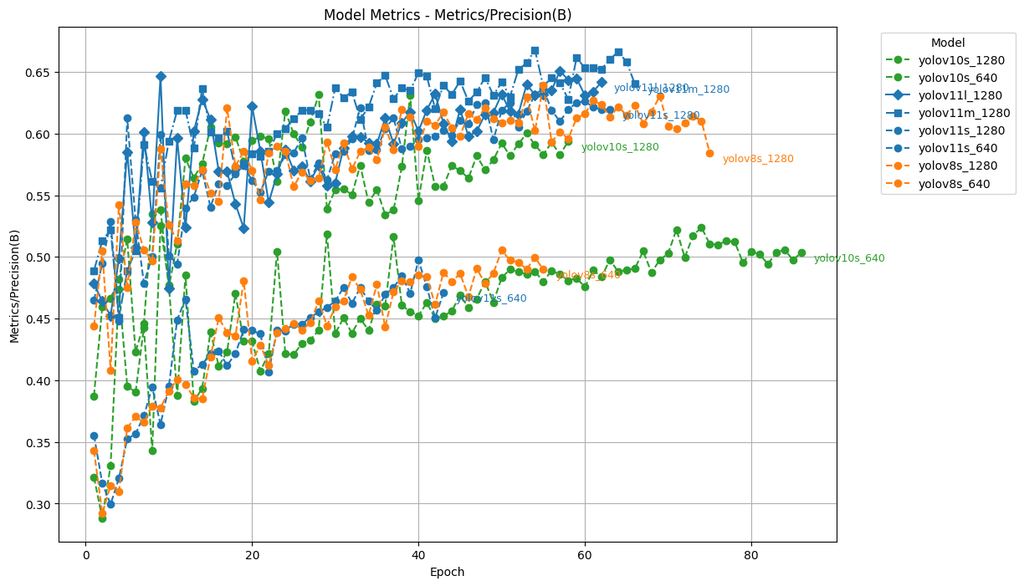

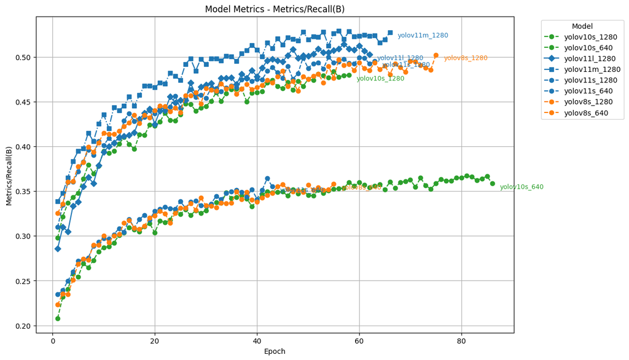

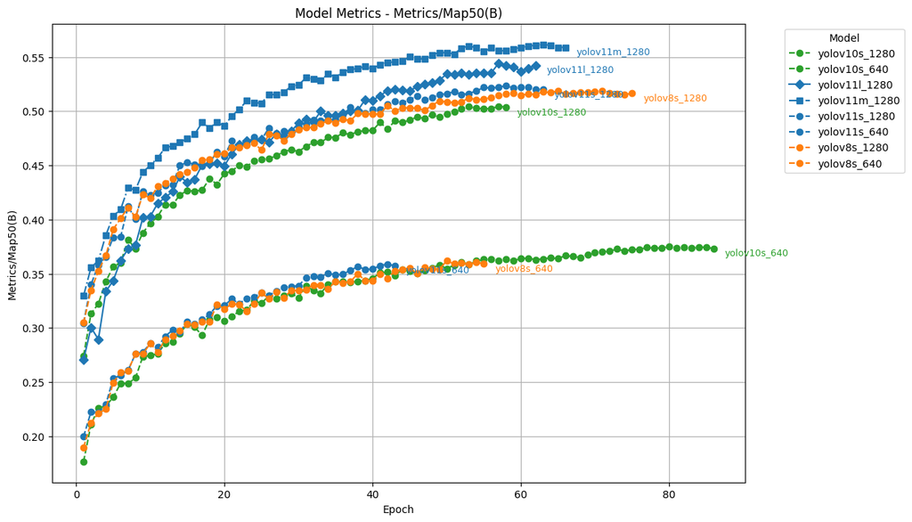

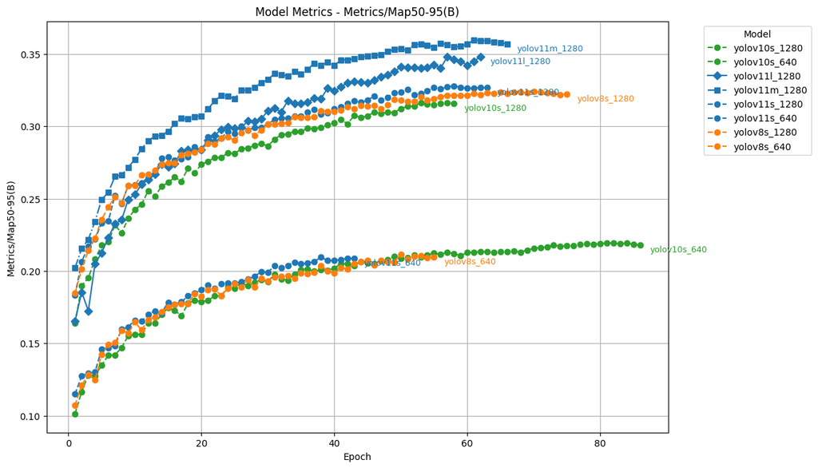

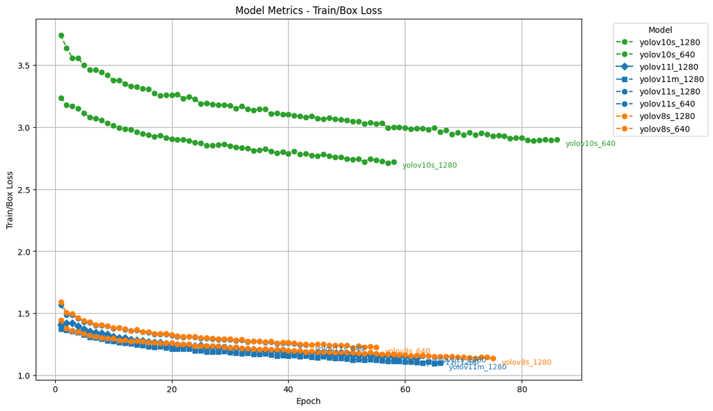

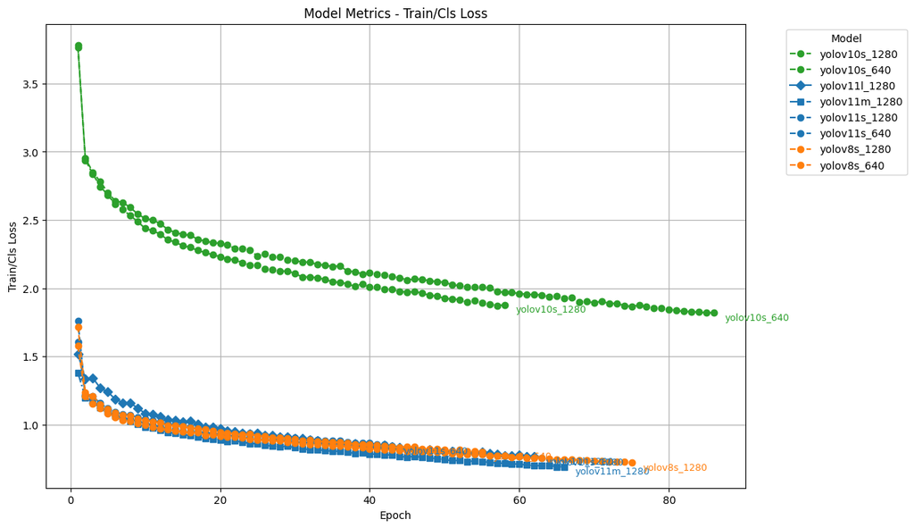

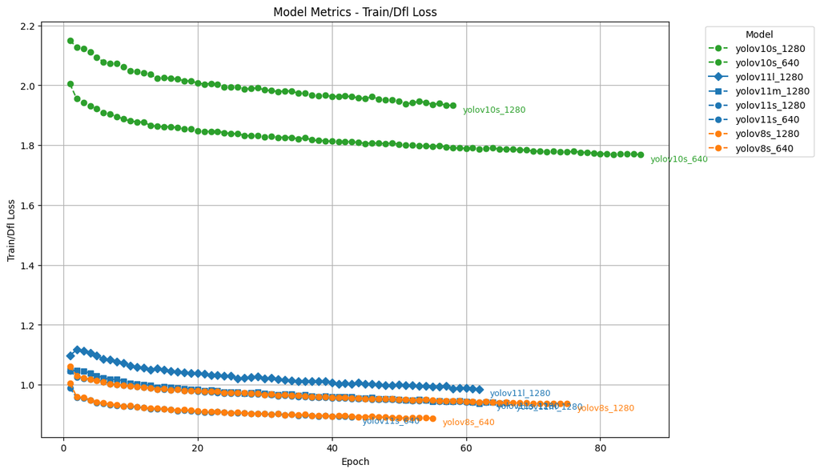

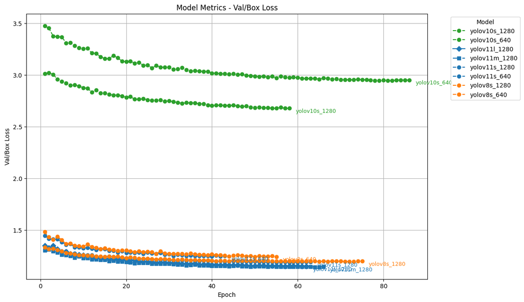

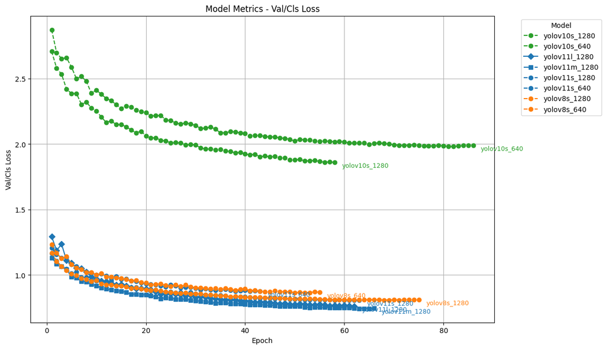

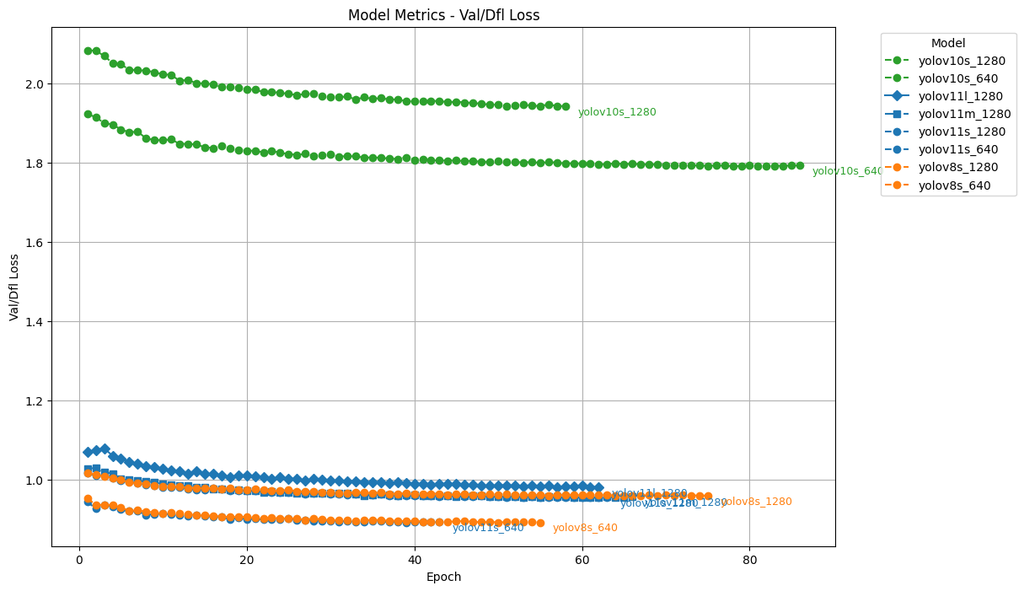

```python
metrics = [
    'metrics/precision(B)', 'metrics/recall(B)', 'metrics/mAP50(B)', 'metrics/mAP50-95(B)',
    'train/box_loss', 'train/cls_loss', 'train/dfl_loss',
    'val/box_loss', 'val/cls_loss', 'val/dfl_loss'
]


df_extended = df.copy()
df_extended['input_size'] = df_extended['model'].apply(lambda x: '1280' if '1280' in x else '640')
df_extended['size_category'] = df_extended['model'].apply(
    lambda x: 'small' if 's_' in x else ('medium' if 'm_' in x else 'large')
)
df_extended['line_style'] = df_extended['size_category'].map({'small': '--', 'medium': '-.', 'large': '-'})
size_marker_map = {'small': 'o', 'medium': 's', 'large': 'D'}


for metric in metrics:
    plt.figure(figsize=(12, 8))

    for (model, group) in df_extended.groupby('model'):
        plt.plot(
            group['epoch'], group[metric],
            label=model, linestyle=group['line_style'].iloc[0],
            marker=size_marker_map[group['size_category'].iloc[0]],
            color=palette_extended[model]
        )

        # Add labels with spacing from the last data point
        plt.text(
            group['epoch'].iloc[-1] + 1.5, group[metric].iloc[-1],
            model, verticalalignment='top', fontsize=9, color=palette_extended[model]
        )

    plt.grid(True)
    plt.title(f"Model Metrics - {metric.replace('_', ' ').title()}")
    plt.xlabel("Epoch")
    plt.ylabel(metric.replace('_', ' ').title())
    plt.legend(title='Model', bbox_to_anchor=(1.05, 1), loc='upper left')
    plt.show()
```

## 3.3 Test Results

- I will create a script to test my best model on an image of me flying my drone to see how it does detecting my car!
- My car before detection!

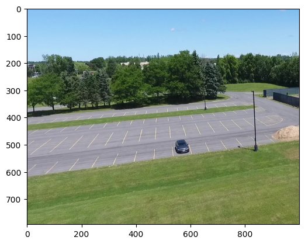

```python
img = plt.imread("/mnt/DATA1/DTSA_5011/Final_Project/DJI_0028_fps24_frame00000040.jpg")
plt.imshow(img)
plt.show()
```

```python
test_script = '''from ultralytics import YOLO



model = YOLO('/mnt/DATA1/DTSA_5011/Final_Project/VisDrone_Models_P5/yolov11m_1280/weights/best.pt')

results = model.predict(['/mnt/DATA1/DTSA_5011/Final_Project/DJI_0028_fps24_frame00000040.jpg'], save=True)

'''
with open("test_script.py","w") as f:
    f.write(test_script)
```

- My car after detection!

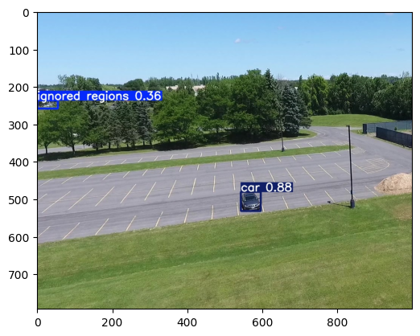

```python
img = plt.imread("/mnt/DATA1/DTSA_5011/Final_Project/runs/detect/predict3/DJI_0028_fps24_frame00000040.jpg")
plt.imshow(img)
plt.show()
```

# 4.0 Discussion/Conclusion